# R Notebook

```r
rm(list=ls())
# Clear environmet of packages
if(is.null(sessionInfo()$otherPkgs) == FALSE)lapply(paste("package:", names(sessionInfo()$otherPkgs), sep=""), detach, character.only = TRUE, unload = TRUE)

library(tidyverse)
library(readr)
library(gridExtra)
library(GGally)
library(htmlTable)
library(stringr)


psam_p36 <- read_csv("psam_p36.csv")
```

# 1. examine the first 10 or 20 observations (rows of data) corresponding to variables of interest (columns) and compare the observed values to the data dictionary (Links to an external site.) for person records

```r
head(psam_p36, 10)
```

| RT | SERIALNO | DIVISION | SPORDER | PUMA | REGION | ST | ADJINC | PWGTP | AGEP | CIT | CITWP | COW | DDRS | DEAR | DEYE | DOUT | DPHY | DRAT | DRATX | DREM | ENG | FER | GCL | GCM | GCR | HINS1 | HINS2 | HINS3 | HINS4 | … |
| --- | --- | --- | --- | --- | --- | --- | --- | --- | --- | --- | --- | --- | --- | --- | --- | --- | --- | --- | --- | --- | --- | --- | --- | --- | --- | --- | --- | --- | --- | --- |
| P | 2.017e+12 | 2 | 01 | 00902 | 1 | 36 | 1011189 | 00122 | 72 | 1 | NA | 1 | 2 | 2 | 2 | 2 | 2 | NA | NA | 2 | NA | NA | 2 | NA | NA | 1 | 2 | 1 | 2 | … |
| P | 2.017e+12 | 2 | 02 | 00902 | 1 | 36 | 1011189 | 00118 | 72 | 1 | NA | 1 | 2 | 2 | 2 | 2 | 2 | NA | NA | 2 | NA | NA | 2 | NA | NA | 1 | 2 | 1 | 2 | … |
| P | 2.017e+12 | 2 | 01 | 04002 | 1 | 36 | 1011189 | 00056 | 31 | 1 | NA | 1 | 2 | 2 | 2 | 2 | 2 | NA | NA | 2 | NA | NA | 2 | NA | NA | 1 | 2 | 2 | 2 | … |
| P | 2.017e+12 | 2 | 02 | 04002 | 1 | 36 | 1011189 | 00058 | 28 | 1 | NA | 1 | 2 | 2 | 2 | 2 | 2 | NA | NA | 2 | NA | 2 | NA | NA | NA | 1 | 2 | 2 | 2 | … |
| P | 2.017e+12 | 2 | 01 | 03803 | 1 | 36 | 1011189 | 00111 | 54 | 1 | NA | 1 | 2 | 2 | 2 | 2 | 2 | NA | NA | 2 | NA | NA | 2 | NA | NA | 1 | 2 | 2 | 2 | … |
| P | 2.017e+12 | 2 | 02 | 03803 | 1 | 36 | 1011189 | 00086 | 45 | 5 | NA | 1 | 2 | 2 | 2 | 2 | 2 | NA | NA | 2 | NA | 2 | 2 | NA | NA | 1 | 2 | 2 | 2 | … |
| P | 2.017e+12 | 2 | 01 | 01400 | 1 | 36 | 1011189 | 00024 | 84 | 1 | NA | NA | 2 | 2 | 2 | 2 | 1 | NA | NA | 2 | NA | NA | 2 | NA | NA | 2 | 2 | 1 | 2 | … |
| P | 2.017e+12 | 2 | 01 | 02002 | 1 | 36 | 1011189 | 00038 | 71 | 1 | NA | 4 | 2 | 2 | 2 | 2 | 2 | NA | NA | 2 | NA | NA | 2 | NA | NA | 1 | 2 | 1 | 2 | … |
| P | 2.017e+12 | 2 | 02 | 02002 | 1 | 36 | 1011189 | 00040 | 68 | 1 | NA | NA | 2 | 2 | 2 | 2 | 2 | NA | NA | 2 | NA | NA | 2 | NA | NA | 1 | 2 | 1 | 2 | … |
| P | 2.017e+12 | 2 | 03 | 02002 | 1 | 36 | 1011189 | 00054 | 37 | 1 | NA | 6 | 2 | 2 | 2 | 2 | 2 | NA | NA | 2 | NA | 2 | 2 | NA | NA | 1 | 2 | 2 | 2 | … |

Comment: - Some data has NA value, but most data is align with the data dictionary

# 2. compute and examine descriptive statistics for the full sample for your state including the minimum, maximum, mean, and median for quantitative variables of interest

```r
psam_p36$ADJINC <- psam_p36$ADJINC/ 1000000
summary(psam_p36$ADJINC)
```

```
##    Min. 1st Qu.  Median    Mean 3rd Qu.    Max.
##   1.011   1.011   1.011   1.011   1.011   1.011
```

```r
class(psam_p36$ADJINC)
```

```
## [1] "numeric"
```

2.1. descriptive statistics for the full sample of qunatitative variables

```r
# convert into qunatitative variable
psam_p36$PERNP <- as.numeric(psam_p36$PERNP)* psam_p36$ADJINC # PERNP: Total person's earnings
psam_p36$AGEP <- as.numeric(psam_p36$AGEP) # person's age
psam_p36$PWGTP <- as.numeric(psam_p36$PWGTP) # person's weight
psam_p36$JWMNP <- as.numeric(psam_p36$JWMNP) # person's travel time

sample_full <- data.frame(PERNP = psam_p36$PERNP, AGEP = psam_p36$AGEP, PWGTP = psam_p36$PWGTP, JWMNP = psam_p36$JWMNP )
# descriptive statistics before cleaning/sample selection
summary(sample_full)
```

```
##      PERNP              AGEP           PWGTP          JWMNP
##  Min.   :  -5966   Min.   : 0.00   Min.   :   2   Min.   :  1.00
##  1st Qu.:      0   1st Qu.:22.00   1st Qu.:  53   1st Qu.: 15.00
##  Median :  13146   Median :42.00   Median :  78   Median : 30.00
##  Mean   :  36331   Mean   :41.57   Mean   : 101   Mean   : 33.28
##  3rd Qu.:  50559   3rd Qu.:60.00   3rd Qu.: 123   3rd Qu.: 45.00
##  Max.   :1060737   Max.   :95.00   Max.   :1532   Max.   :138.00
##  NA's   :33427                                    NA's   :109463
```

Comment: - too many NA’s, delete those row in PERNP. - Mean is high but the median value is 1/3 of mean - Because 1st Qu. is 0 dollars, there might be people who does not work at all (they might live on devidend or pension, etc)

2.2. Sample selection 1

```r
psam_p36 <- subset(psam_p36, !is.na(psam_p36$PERNP)) # get rid of N/A: No information about one's earnings
psam_p36 <- subset(psam_p36, !is.na(psam_p36$MIL)) # get rid of N/A for non-eligible samples to join military (less than 17 years old)
psam_p36$MIL <- factor(psam_p36$MIL)


levels(psam_p36$MIL)[levels(psam_p36$MIL)=="1"] <- "Now active duty"
levels(psam_p36$MIL)[levels(psam_p36$MIL)=="2"] <- "Active duty in the past"
levels(psam_p36$MIL)[levels(psam_p36$MIL)=="3"] <- "Active duty in the past"
levels(psam_p36$MIL)[levels(psam_p36$MIL)=="4"] <- "Never served"

psam_p36 <- subset(psam_p36, psam_p36$MIL != "Now active duty") # get rid of who are currently in the military
psam_p36 <- subset(psam_p36, !factor(psam_p36$ESR) == "6" ) # get rid of samples not in labor force
psam_p36 <- subset(psam_p36, !factor(psam_p36$CIT) == "5" ) # Not a citizen of the U.S.
psam_p36 <- subset(psam_p36, as.numeric(psam_p36$AGEP) < 65 ) # less than 65 years old
psam_p36 <- subset(psam_p36, factor(psam_p36$ESR) != 6 ) # Exclude "Not in labor force"
# psam_p36 <- subset(psam_p36, factor(psam_p36$ESR) != 1 ) # Exclude "Not in labor force"
psam_p36 <- subset(psam_p36, as.numeric(psam_p36$PERNP) > 0 ) # less than 65 years old


str(psam_p36$MIL)
```

```
##  Factor w/ 3 levels "Now active duty",..: 3 3 3 3 3 3 3 3 2 3 ...
```

```r
sample_selection_1 <- data.frame(PERNP = psam_p36$PERNP, AGEP = psam_p36$AGEP, PWGTP = psam_p36$PWGTP, JWMNP = psam_p36$JWMNP ,MIL = psam_p36$MIL, SOCP = factor(psam_p36$SOCP), NWLK = factor(psam_p36$NWLK))
# descriptive statistics
summary((sample_selection_1))
```

```
##      PERNP              AGEP           PWGTP            JWMNP
##  Min.   :      4   Min.   :17.00   Min.   :   2.0   Min.   :  1.00
##  1st Qu.:  20224   1st Qu.:30.00   1st Qu.:  55.0   1st Qu.: 15.00
##  Median :  42470   Median :42.00   Median :  79.0   Median : 25.00
##  Mean   :  61722   Mean   :41.83   Mean   : 101.6   Mean   : 32.97
##  3rd Qu.:  74828   3rd Qu.:53.00   3rd Qu.: 123.0   3rd Qu.: 45.00
##  Max.   :1060737   Max.   :64.00   Max.   :1532.0   Max.   :138.00
##                                                     NA's   :7203
##                       MIL             SOCP       NWLK
##  Now active duty        :    0   252020 : 2840   1: 2553
##  Active duty in the past: 2948   119XXX : 2298   2: 4042
##  Never served           :77195   436010 : 2234   3:73548
##                                  291141 : 1829
##                                  412031 : 1638
##                                  412010 : 1578
##                                  (Other):67726
```

Comment: - the data is cleaner - the median and mean for earnings(PERNP) are still far from each other

# 3. generate and examine histograms for quantitative variables of interest

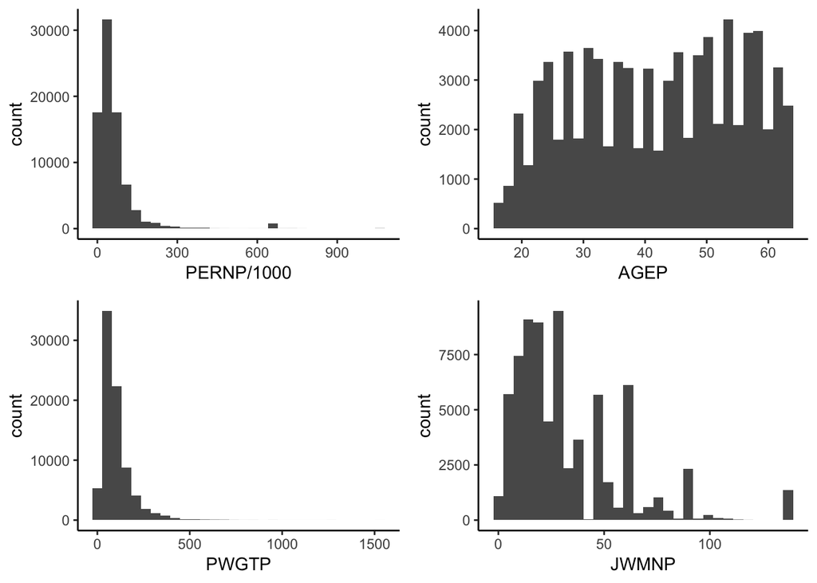

```r
# earning in 1000 in New York State
grid.arrange(
ggplot(data = psam_p36, mapping = aes(x = PERNP/1000)) +
    theme_classic() +
    geom_histogram(),

ggplot(data = psam_p36, mapping = aes(x = AGEP)) +
    theme_classic() +
    geom_histogram(),

ggplot(data = psam_p36, mapping = aes(x = PWGTP)) +
    theme_classic() +
    geom_histogram(),

ggplot(data = psam_p36, mapping = aes(x = JWMNP)) +
    theme_classic() +
    geom_histogram(),
ncol = 2 )
```

- Most of the samples has earning around 0 to 300,000

# 4. generate and examine bar charts/graphs for qualitative variables of interest

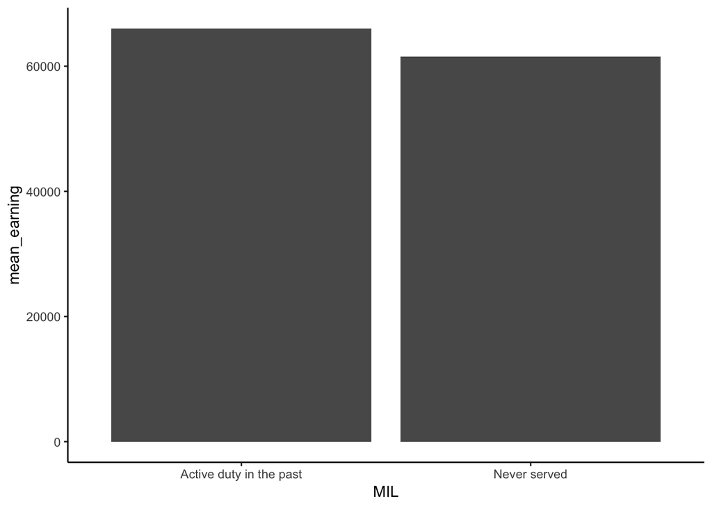

```r
# mean earnings by Military Service
psam_p36 %>%
  group_by(MIL) %>%
  summarise(mean_earning = mean(PERNP)) %>%
  ggplot(aes(x = MIL , y = mean_earning)) +
  theme_classic() +
  geom_bar(stat = "identity", position = "dodge")
```

- Samples with active duty experience have greater mean earnings.

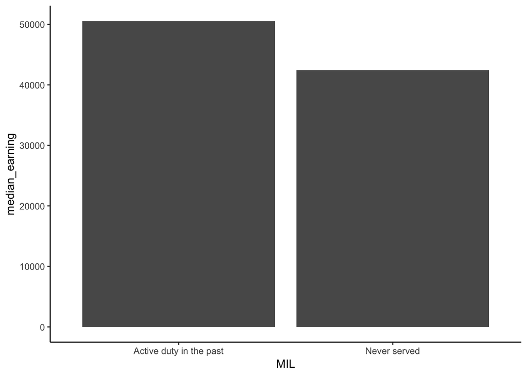

```r
psam_p36 %>%
  group_by(MIL) %>%
  summarise(median_earning = median(PERNP)) %>%
  ggplot(aes(x = MIL , y = median_earning)) +
  theme_classic() +
  geom_bar(stat = "identity", position = "dodge")
```

- Median is also the same

```r
# Clean the data(Race and ethnicity)
psam_p36$RAC1P <- factor(psam_p36$RAC1P)
levels(psam_p36$RAC1P)[levels(psam_p36$RAC1P)=="1"] <- "White"
levels(psam_p36$RAC1P)[levels(psam_p36$RAC1P)=="2"] <- "African American"
levels(psam_p36$RAC1P)[levels(psam_p36$RAC1P)=="3"] <- "American Indian"
levels(psam_p36$RAC1P)[levels(psam_p36$RAC1P)=="4"] <- "Alaska Native"
levels(psam_p36$RAC1P)[levels(psam_p36$RAC1P)=="5"] <- "Other Native"
levels(psam_p36$RAC1P)[levels(psam_p36$RAC1P)=="6"] <- "Asian"
levels(psam_p36$RAC1P)[levels(psam_p36$RAC1P)=="7"] <- "Native Hawaiian"
levels(psam_p36$RAC1P)[levels(psam_p36$RAC1P)=="8"] <- "Some other race"
levels(psam_p36$RAC1P)[levels(psam_p36$RAC1P)=="9"] <- "Two or More Races"

# levels(psam_p36$RAC1P)
# summary(psam_p36$RAC1P)
```

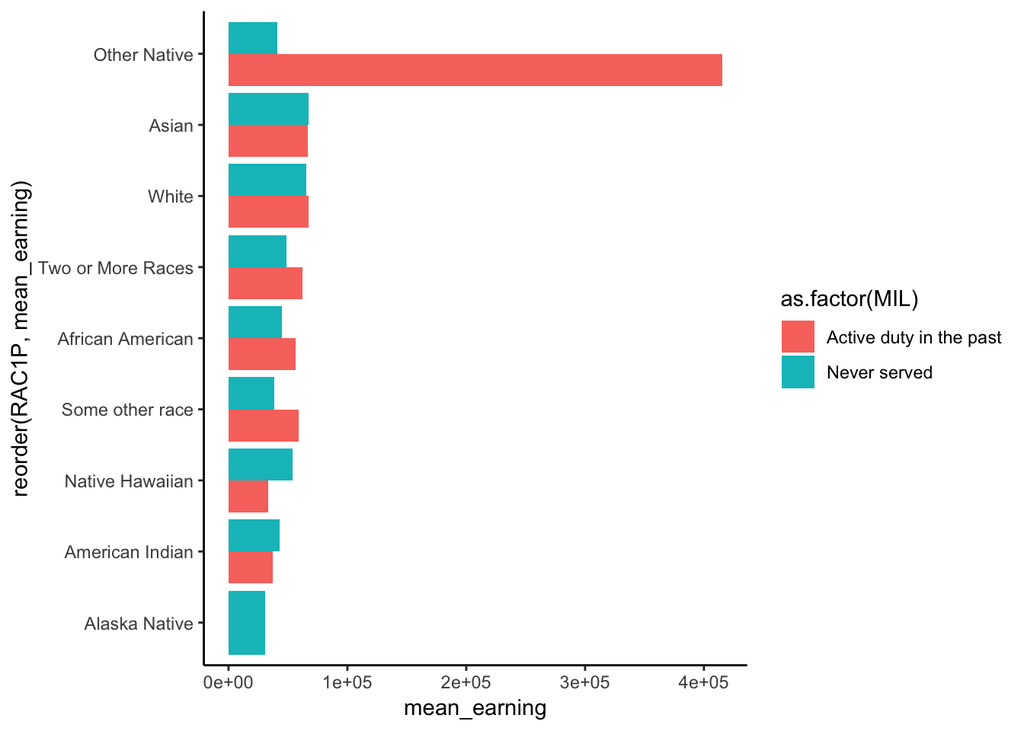

```r
psam_p36 %>%
    group_by(MIL, RAC1P) %>%
    summarise(mean_earning = mean(PERNP)) %>%
    ggplot(mapping = aes(x = reorder(RAC1P, mean_earning) , y = mean_earning, fill = as.factor(MIL))) +
    geom_bar(stat = "identity", position = "dodge") +
    theme_classic() +
    coord_flip()
```

- we have limitation on examine some of the races due to the lack of data

```r
# Sample selection 2: get rid of variables with insufficint data for races and military service
psam_p36 <- subset(psam_p36, psam_p36$RAC1P != "Alaska Native")
psam_p36 <- subset(psam_p36, psam_p36$RAC1P != "Some other race") #
psam_p36 <- subset(psam_p36, psam_p36$RAC1P != "Other Native") #
psam_p36 <- subset(psam_p36, psam_p36$RAC1P != "Native Hawaiian") #
psam_p36 <- subset(psam_p36, psam_p36$RAC1P != "Two or More Races") #
```

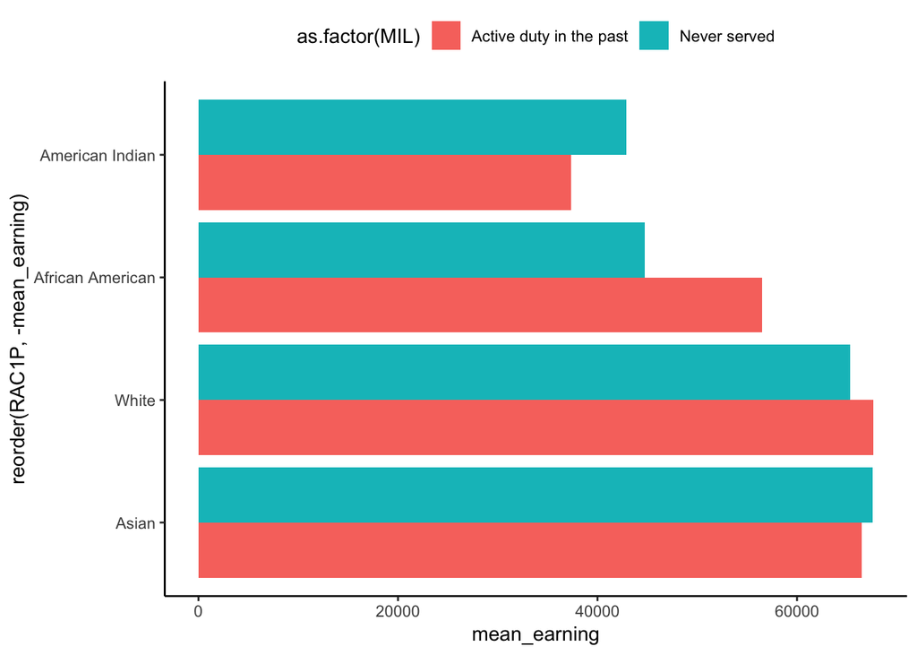

```r
psam_p36 %>%
    group_by(MIL, RAC1P) %>%
    summarise(mean_earning = mean(PERNP)) %>%
    ggplot(mapping = aes(x = reorder(RAC1P, -mean_earning) , y = mean_earning, fill = as.factor(MIL))) +
    geom_bar(stat = "identity", position = "dodge") +
    theme_classic() +
    theme(legend.position = "top") +
    coord_flip()
```

# 5. generate and examine cross tabulations, scatterplots, and/or correlation coefficients of interest

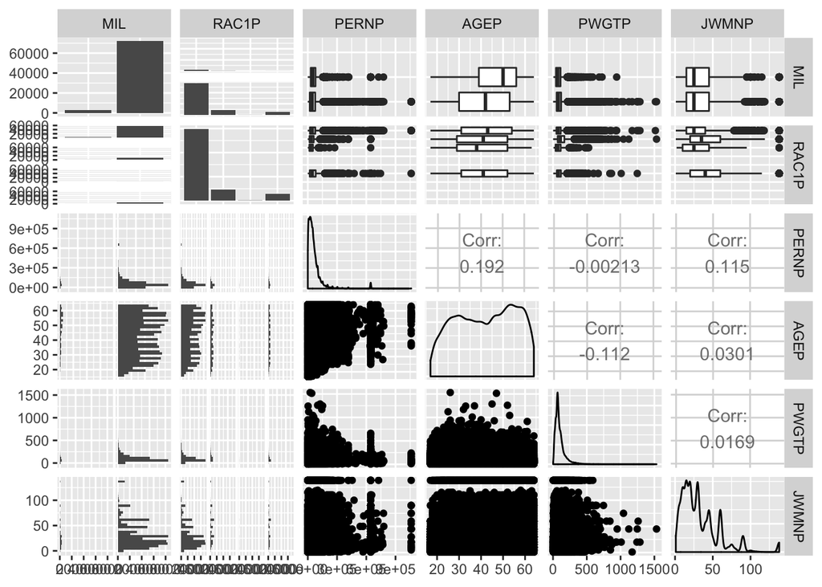

```r
#Correlation
psam_p36 %>%
  select(MIL, RAC1P, PERNP, AGEP, PWGTP, JWMNP) %>%
  ggpairs()
```

# rationale for sample selection criteria

- get rid of N/A: No information about one’s earnings
- get rid of N/A for non-eligible samples to join military (less than 17 years old)
- get rid of samples not looking for work because we use earnings instead of income
- get rid of races which has small observations to conduct EDA for earnings and military

# descriptive statistics (after imposing sample selection criteria)

```r
sample <- data.frame(RAC1P = psam_p36$RAC1P, MIL = psam_p36$MIL, PERNP = psam_p36$PERNP, AGEP = psam_p36$AGEP, PWGTP = psam_p36$PWGTP, JWMNP = psam_p36$JWMNP)
summary(sample)
```

```
##               RAC1P                            MIL
##  White           :59607   Now active duty        :    0
##  African American: 9058   Active duty in the past: 2799
##  Asian           : 5893   Never served           :71972
##  American Indian :  213
##  Alaska Native   :    0
##  Other Native    :    0
##  (Other)         :    0
##      PERNP              AGEP          PWGTP             JWMNP
##  Min.   :      4   Min.   :17.0   Min.   :   2.00   Min.   :  1.00
##  1st Qu.:  21235   1st Qu.:31.0   1st Qu.:  54.00   1st Qu.: 15.00
##  Median :  44088   Median :43.0   Median :  78.00   Median : 25.00
##  Mean   :  63086   Mean   :42.1   Mean   :  99.07   Mean   : 32.56
##  3rd Qu.:  75839   3rd Qu.:54.0   3rd Qu.: 120.00   3rd Qu.: 45.00
##  Max.   :1060737   Max.   :64.0   Max.   :1532.00   Max.   :138.00
##                                                     NA's   :6663
```

# Regression

```r
psam_p36 <- mutate(psam_p36,SOCP_group = case_when(str_detect(SOCP, "^11") ~ "Management",
                          str_detect(SOCP, "^13") ~ "Biz & Finance",
                          str_detect(SOCP, "^15") ~ "CS & Math",
                          str_detect(SOCP, "^17") ~ "Architect & Engineer",
                          str_detect(SOCP, "^19") ~ "Science",
                          str_detect(SOCP, "^23") ~ "Legal",
                          str_detect(SOCP, "^25") ~ "Education",
                          str_detect(SOCP, "^27") ~ "Entertainment",
                          str_detect(SOCP, "^29") ~ "Health",
                          str_detect(SOCP, "^31") ~ "Health support",
                          str_detect(SOCP, "^33") ~ "Protective",
                          str_detect(SOCP, "^35") ~ "Food",
                          str_detect(SOCP, "^37") ~ "Cleaning",
                          str_detect(SOCP, "^39") ~ "Personal care",
                          str_detect(SOCP, "^41") ~ "Sales",
                          str_detect(SOCP, "^43") ~ "Office Admin",
                          str_detect(SOCP, "^45") ~ "Farming",
                          str_detect(SOCP, "^47") ~ "Construction",
                          str_detect(SOCP, "^49") ~ "Mechanics",
                          str_detect(SOCP, "^51") ~ "Production",
                          str_detect(SOCP, "^53") ~ "Transportation",
                          str_detect(SOCP, "^55") ~ "Military"))
```

```r
psam_p36$SOCP_group <- factor(psam_p36$SOCP_group)
summary(psam_p36$SOCP_group)
```

```
## Architect & Engineer        Biz & Finance             Cleaning
##                 1217                 4185                 2226
##         Construction            CS & Math            Education
##                 3091                 2083                 6157
##        Entertainment              Farming                 Food
##                 2433                  256                 3282
##               Health       Health support                Legal
##                 5143                 1869                 1299
##           Management            Mechanics             Military
##                 8238                 1946                    6
##         Office Admin        Personal care           Production
##                10064                 2879                 2828
##           Protective                Sales              Science
##                 2172                 7159                  691
##       Transportation                 NA's
##                 3816                 1731
```

## simple regression - MIL

```r
singleRegression <- lm(PERNP ~ MIL, data = psam_p36)
# print(singleRegression)
summary(singleRegression)
```

```
##
## Call:
## lm(formula = PERNP ~ MIL, data = psam_p36)
##
## Residuals:
##    Min     1Q Median     3Q    Max
## -66087 -41932 -19483  12875 997773
##
## Coefficients:
##                 Estimate Std. Error t value Pr(>|t|)
## (Intercept)        66219       1565  42.321   <2e-16 ***
## MILNever served    -3254       1595  -2.041   0.0413 *
## ---
## Signif. codes:  0 '***' 0.001 '**' 0.01 '*' 0.05 '.' 0.1 ' ' 1
##
## Residual standard error: 82780 on 74769 degrees of freedom
## Multiple R-squared:  5.569e-05,  Adjusted R-squared:  4.232e-05
## F-statistic: 4.164 on 1 and 74769 DF,  p-value: 0.04129
```

## Multiple regression - RAC1P (race/ethnicity) added

```r
ml_regression2 <- lm(PERNP ~ MIL + RAC1P, data = psam_p36)
# print(ml_regression1)
summary(ml_regression2)
```

```
##
## Call:
## lm(formula = PERNP ~ MIL + RAC1P, data = psam_p36)
##
## Residuals:
##    Min     1Q Median     3Q    Max
## -68686 -41047 -17992  12597 995422
##
## Coefficients:
##                       Estimate Std. Error t value Pr(>|t|)
## (Intercept)            68515.5     1563.8  43.815  < 2e-16 ***
## MILNever served        -3200.2     1590.6  -2.012   0.0442 *
## RAC1PAfrican American -20274.6      930.5 -21.790  < 2e-16 ***
## RAC1PAmerican Indian  -23022.3     5663.3  -4.065  4.8e-05 ***
## RAC1PAsian              2192.4     1127.4   1.945   0.0518 .
## ---
## Signif. codes:  0 '***' 0.001 '**' 0.01 '*' 0.05 '.' 0.1 ' ' 1
##
## Residual standard error: 82500 on 74766 degrees of freedom
## Multiple R-squared:  0.006793,   Adjusted R-squared:  0.00674
## F-statistic: 127.8 on 4 and 74766 DF,  p-value: < 2.2e-16
```

- a person never served military has lower earnings by -3200 on average relative to a person who have served military before
- a white person has higher earnings by -20274.6 to African American and -23022.3 to American Indian on average. But to Asian, a white person has lower

# Multiple regression 2 - added all other possible variables

```r
psam_p36$SOCP <- factor(psam_p36$SOCP)
psam_p36$SEX <- factor(psam_p36$SEX)

ml_regression2 <- lm(PERNP ~ MIL + RAC1P + AGEP + SEX  + PWGTP + JWMNP + SOCP_group, data = psam_p36)
# print(ml_regression1)
summary(ml_regression2)
```

```
##
## Call:
## lm(formula = PERNP ~ MIL + RAC1P + AGEP + SEX + PWGTP + JWMNP +
##     SOCP_group, data = psam_p36)
##
## Residuals:
##     Min      1Q  Median      3Q     Max
## -193885  -32814   -9769   14287 1007836
##
## Coefficients:
##                            Estimate Std. Error t value Pr(>|t|)
## (Intercept)               25930.786   2971.947   8.725  < 2e-16 ***
## MILNever served            8275.811   1572.361   5.263 1.42e-07 ***
## RAC1PAfrican American    -13984.383    960.737 -14.556  < 2e-16 ***
## RAC1PAmerican Indian     -16365.432   5588.985  -2.928 0.003411 **
## RAC1PAsian                -2855.770   1101.942  -2.592 0.009556 **
## AGEP                       1090.862     23.176  47.069  < 2e-16 ***
## SEX2                     -28099.029    666.315 -42.171  < 2e-16 ***
## PWGTP                        25.984      3.913   6.641 3.15e-11 ***
## JWMNP                       271.390     11.683  23.228  < 2e-16 ***
## SOCP_groupBiz & Finance   23087.973   2585.819   8.929  < 2e-16 ***
## SOCP_groupCleaning       -47910.906   2834.515 -16.903  < 2e-16 ***
## SOCP_groupConstruction   -37279.823   2689.531 -13.861  < 2e-16 ***
## SOCP_groupCS & Math       10284.299   2873.065   3.580 0.000344 ***
## SOCP_groupEducation      -12289.218   2503.733  -4.908 9.21e-07 ***
## SOCP_groupEntertainment   -7553.985   2859.162  -2.642 0.008243 **
## SOCP_groupFarming        -51538.267   5765.337  -8.939  < 2e-16 ***
## SOCP_groupFood           -43448.201   2678.508 -16.221  < 2e-16 ***
## SOCP_groupHealth          22430.111   2536.932   8.841  < 2e-16 ***
## SOCP_groupHealth support -33546.245   2953.352 -11.359  < 2e-16 ***
## SOCP_groupLegal           76323.303   3154.326  24.196  < 2e-16 ***
## SOCP_groupManagement      31004.805   2430.290  12.758  < 2e-16 ***
## SOCP_groupMechanics      -33953.888   2880.144 -11.789  < 2e-16 ***
## SOCP_groupMilitary       -29399.307  43994.066  -0.668 0.503972
## SOCP_groupOffice Admin   -28254.686   2421.366 -11.669  < 2e-16 ***
## SOCP_groupPersonal care  -39418.513   2759.520 -14.285  < 2e-16 ***
## SOCP_groupProduction     -38372.667   2703.044 -14.196  < 2e-16 ***
## SOCP_groupProtective     -12476.212   2820.361  -4.424 9.72e-06 ***
## SOCP_groupSales           -9419.168   2461.816  -3.826 0.000130 ***
## SOCP_groupScience          7164.706   3754.825   1.908 0.056378 .
## SOCP_groupTransportation -43803.791   2602.676 -16.830  < 2e-16 ***
## ---
## Signif. codes:  0 '***' 0.001 '**' 0.01 '*' 0.05 '.' 0.1 ' ' 1
##
## Residual standard error: 76050 on 66490 degrees of freedom
##   (8251 observations deleted due to missingness)
## Multiple R-squared:  0.1871, Adjusted R-squared:  0.1868
## F-statistic: 527.8 on 29 and 66490 DF,  p-value: < 2.2e-16
```

```r
# str(ml_regression2)
# compare to Served military, White(RAC1P) and SOCP_group(Architect & Engineer)
```

- R squared improved
- On this regression model, people never served military has higher earnings by 8275.811 on average, relative to people served military before
- Type of work seems to dominate the earnings

```r
ml_regression3 <- lm(PERNP ~ MIL + RAC1P + AGEP + SEX  + PWGTP + SOCP_group, data = psam_p36) # without JWMNP
# print(ml_regression1)
summary(ml_regression3)
```

```
##
## Call:
## lm(formula = PERNP ~ MIL + RAC1P + AGEP + SEX + PWGTP + SOCP_group,
##     data = psam_p36)
##
## Residuals:
##     Min      1Q  Median      3Q     Max
## -185245  -32576   -9794   13951 1002126
##
## Coefficients:
##                            Estimate Std. Error t value Pr(>|t|)
## (Intercept)               34168.900   2822.063  12.108  < 2e-16 ***
## MILNever served            7878.068   1499.076   5.255 1.48e-07 ***
## RAC1PAfrican American    -10518.125    898.259 -11.709  < 2e-16 ***
## RAC1PAmerican Indian     -11864.976   5250.611  -2.260 0.023841 *
## RAC1PAsian                  353.905   1048.391   0.338 0.735688
## AGEP                       1091.504     21.865  49.919  < 2e-16 ***
## SEX2                     -27505.085    632.419 -43.492  < 2e-16 ***
## PWGTP                        24.094      3.681   6.545 5.99e-11 ***
## SOCP_groupBiz & Finance   23265.462   2477.465   9.391  < 2e-16 ***
## SOCP_groupCleaning       -49507.777   2704.435 -18.306  < 2e-16 ***
## SOCP_groupConstruction   -37670.397   2565.151 -14.685  < 2e-16 ***
## SOCP_groupCS & Math       10554.248   2734.280   3.860 0.000113 ***
## SOCP_groupEducation      -14100.630   2402.549  -5.869 4.40e-09 ***
## SOCP_groupEntertainment  -10066.918   2668.517  -3.772 0.000162 ***
## SOCP_groupFarming        -56041.799   5209.792 -10.757  < 2e-16 ***
## SOCP_groupFood           -45897.327   2560.143 -17.928  < 2e-16 ***
## SOCP_groupHealth          21336.968   2441.838   8.738  < 2e-16 ***
## SOCP_groupHealth support -33373.961   2835.492 -11.770  < 2e-16 ***
## SOCP_groupLegal           72184.203   3028.741  23.833  < 2e-16 ***
## SOCP_groupManagement      29918.746   2331.658  12.832  < 2e-16 ***
## SOCP_groupMechanics      -34635.762   2770.532 -12.501  < 2e-16 ***
## SOCP_groupMilitary       -25771.670  31028.491  -0.831 0.406213
## SOCP_groupOffice Admin   -29157.477   2324.033 -12.546  < 2e-16 ***
## SOCP_groupPersonal care  -40878.465   2618.580 -15.611  < 2e-16 ***
## SOCP_groupProduction     -39708.426   2597.435 -15.288  < 2e-16 ***
## SOCP_groupProtective     -12787.639   2716.680  -4.707 2.52e-06 ***
## SOCP_groupSales          -10988.474   2358.402  -4.659 3.18e-06 ***
## SOCP_groupScience          7476.786   3616.062   2.068 0.038676 *
## SOCP_groupTransportation -45233.675   2495.879 -18.123  < 2e-16 ***
## ---
## Signif. codes:  0 '***' 0.001 '**' 0.01 '*' 0.05 '.' 0.1 ' ' 1
##
## Residual standard error: 75730 on 73011 degrees of freedom
##   (1731 observations deleted due to missingness)
## Multiple R-squared:  0.1778, Adjusted R-squared:  0.1775
## F-statistic:   564 on 28 and 73011 DF,  p-value: < 2.2e-16
```

```r
summary(psam_p36$RAC1P)
```

```
##             White  African American   American Indian     Alaska Native
##             59607              9058               213                 0
##      Other Native             Asian   Native Hawaiian   Some other race
##                 0              5893                 0                 0
## Two or More Races
##                 0
```